# Visualizing Earnings Based On College Majors

Return to main portfolio: https://xotofloyt.github.io/

This is a practice project that I performed during my studies in order to apply some visualization techniques to a data set.

In this project I will be working with a dataset on the job outcomes of students who graduated from college between 2010 and 2012.

This data set was cleaned up and provided by FiveThirtyEight.

I will be trying to answer the following questions:

1- Do students in more popular majors make more money?

2- How many majors are predominantly male? Predominantly female?

3- Which category of majors have the most students?

# 1 Preparing the coding environment - importing libraries.

- Our plan is to use visualisations to answer certain questions about our data.
- We will start by importing the pandas and matplotlib libraries.
- We will read in the revent_grads.csv file

```python
#importing Pandas and Matplotlib Libraries
import pandas as pd
import matplotlib.pyplot as plt

%matplotlib inline

recent_grads = pd.read_csv('recent-grads.csv')

# printing the first row of data
print(recent_grads.iloc[0])
print('\n')
```

```
Rank                                        1
Major_code                               2419
Major                   PETROLEUM ENGINEERING
Total                                  2339.0
Men                                    2057.0
Women                                   282.0
Major_category                    Engineering
ShareWomen                           0.120564
Sample_size                                36
Employed                                 1976
Full_time                                1849
Part_time                                 270
Full_time_year_round                     1207
Unemployed                                 37
Unemployment_rate                    0.018381
Median                                 110000
P25th                                   95000
P75th                                  125000
College_jobs                             1534
Non_college_jobs                          364
Low_wage_jobs                             193
Name: 0, dtype: object
```

```python
# printing the first 5 rows of data
print(recent_grads.head())
print('\n')
```

```
   Rank  Major_code                                      Major    Total  \
0     1        2419                      PETROLEUM ENGINEERING   2339.0
1     2        2416             MINING AND MINERAL ENGINEERING    756.0
2     3        2415                  METALLURGICAL ENGINEERING    856.0
3     4        2417  NAVAL ARCHITECTURE AND MARINE ENGINEERING   1258.0
4     5        2405                       CHEMICAL ENGINEERING  32260.0

       Men    Women Major_category  ShareWomen  Sample_size  Employed  ...  \
0   2057.0    282.0    Engineering    0.120564           36      1976  ...
1    679.0     77.0    Engineering    0.101852            7       640  ...
2    725.0    131.0    Engineering    0.153037            3       648  ...
3   1123.0    135.0    Engineering    0.107313           16       758  ...
4  21239.0  11021.0    Engineering    0.341631          289     25694  ...

   Part_time  Full_time_year_round  Unemployed  Unemployment_rate  Median  \
0        270                  1207          37           0.018381  110000
1        170                   388          85           0.117241   75000
2        133                   340          16           0.024096   73000
3        150                   692          40           0.050125   70000
4       5180                 16697        1672           0.061098   65000

   P25th   P75th  College_jobs  Non_college_jobs  Low_wage_jobs
0  95000  125000          1534               364            193
1  55000   90000           350               257             50
2  50000  105000           456               176              0
3  43000   80000           529               102              0
4  50000   75000         18314              4440            972

[5 rows x 21 columns]
```

```python
# printing the last 5 rows of data
print(recent_grads.tail())
print('\n')
```

```
     Rank  Major_code                   Major   Total     Men   Women  \
168   169        3609                 ZOOLOGY  8409.0  3050.0  5359.0
169   170        5201  EDUCATIONAL PSYCHOLOGY  2854.0   522.0  2332.0
170   171        5202     CLINICAL PSYCHOLOGY  2838.0   568.0  2270.0
171   172        5203   COUNSELING PSYCHOLOGY  4626.0   931.0  3695.0
172   173        3501         LIBRARY SCIENCE  1098.0   134.0   964.0

               Major_category  ShareWomen  Sample_size  Employed  ...  \
168    Biology & Life Science    0.637293           47      6259  ...
169  Psychology & Social Work    0.817099            7      2125  ...
170  Psychology & Social Work    0.799859           13      2101  ...
171  Psychology & Social Work    0.798746           21      3777  ...
172                 Education    0.877960            2       742  ...

     Part_time  Full_time_year_round  Unemployed  Unemployment_rate  Median  \
168       2190                  3602         304           0.046320   26000
169        572                  1211         148           0.065112   25000
170        648                  1293         368           0.149048   25000
171        965                  2738         214           0.053621   23400
172        237                   410          87           0.104946   22000

     P25th  P75th  College_jobs  Non_college_jobs  Low_wage_jobs
168  20000  39000          2771              2947            743
169  24000  34000          1488               615             82
170  25000  40000           986               870            622
171  19200  26000          2403              1245            308
172  20000  22000           288               338            192

[5 rows x 21 columns]
```

```python
# calculating some summary statistics about our data
recent_grads.describe()
```

|  | Rank | Major_code | Total | Men | Women | ShareWomen | Sample_size | Employed | Full_time | Part_time | Full_time_year_round | Unemployed | Unemployment_rate | Median | P25th | P75th | College_jobs | Non_college_jobs | Low_wage_jobs |
| --- | --- | --- | --- | --- | --- | --- | --- | --- | --- | --- | --- | --- | --- | --- | --- | --- | --- | --- | --- |
| count | 173.000000 | 173.000000 | 172.000000 | 172.000000 | 172.000000 | 172.000000 | 173.000000 | 173.000000 | 173.000000 | 173.000000 | 173.000000 | 173.000000 | 173.000000 | 173.000000 | 173.000000 | 173.000000 | 173.000000 | 173.000000 | 173.000000 |
| mean | 87.000000 | 3879.815029 | 39370.081395 | 16723.406977 | 22646.674419 | 0.522223 | 356.080925 | 31192.763006 | 26029.306358 | 8832.398844 | 19694.427746 | 2416.329480 | 0.068191 | 40151.445087 | 29501.445087 | 51494.219653 | 12322.635838 | 13284.497110 | 3859.017341 |
| std | 50.084928 | 1687.753140 | 63483.491009 | 28122.433474 | 41057.330740 | 0.231205 | 618.361022 | 50675.002241 | 42869.655092 | 14648.179473 | 33160.941514 | 4112.803148 | 0.030331 | 11470.181802 | 9166.005235 | 14906.279740 | 21299.868863 | 23789.655363 | 6944.998579 |
| min | 1.000000 | 1100.000000 | 124.000000 | 119.000000 | 0.000000 | 0.000000 | 2.000000 | 0.000000 | 111.000000 | 0.000000 | 111.000000 | 0.000000 | 0.000000 | 22000.000000 | 18500.000000 | 22000.000000 | 0.000000 | 0.000000 | 0.000000 |
| 25% | 44.000000 | 2403.000000 | 4549.750000 | 2177.500000 | 1778.250000 | 0.336026 | 39.000000 | 3608.000000 | 3154.000000 | 1030.000000 | 2453.000000 | 304.000000 | 0.050306 | 33000.000000 | 24000.000000 | 42000.000000 | 1675.000000 | 1591.000000 | 340.000000 |
| 50% | 87.000000 | 3608.000000 | 15104.000000 | 5434.000000 | 8386.500000 | 0.534024 | 130.000000 | 11797.000000 | 10048.000000 | 3299.000000 | 7413.000000 | 893.000000 | 0.067961 | 36000.000000 | 27000.000000 | 47000.000000 | 4390.000000 | 4595.000000 | 1231.000000 |
| 75% | 130.000000 | 5503.000000 | 38909.750000 | 14631.000000 | 22553.750000 | 0.703299 | 338.000000 | 31433.000000 | 25147.000000 | 9948.000000 | 16891.000000 | 2393.000000 | 0.087557 | 45000.000000 | 33000.000000 | 60000.000000 | 14444.000000 | 11783.000000 | 3466.000000 |
| max | 173.000000 | 6403.000000 | 393735.000000 | 173809.000000 | 307087.000000 | 0.968954 | 4212.000000 | 307933.000000 | 251540.000000 | 115172.000000 | 199897.000000 | 28169.000000 | 0.177226 | 110000.000000 | 95000.000000 | 125000.000000 | 151643.000000 | 148395.000000 | 48207.000000 |

```python
#Checking detailed information about column data types:
recent_grads.info()
```

```
<class 'pandas.core.frame.DataFrame'>
RangeIndex: 173 entries, 0 to 172
Data columns (total 21 columns):
 #   Column                Non-Null Count  Dtype
---  ------                --------------  -----
 0   Rank                  173 non-null    int64
 1   Major_code            173 non-null    int64
 2   Major                 173 non-null    object
 3   Total                 172 non-null    float64
 4   Men                   172 non-null    float64
 5   Women                 172 non-null    float64
 6   Major_category        173 non-null    object
 7   ShareWomen            172 non-null    float64
 8   Sample_size           173 non-null    int64
 9   Employed              173 non-null    int64
 10  Full_time             173 non-null    int64
 11  Part_time             173 non-null    int64
 12  Full_time_year_round  173 non-null    int64
 13  Unemployed            173 non-null    int64
 14  Unemployment_rate     173 non-null    float64
 15  Median                173 non-null    int64
 16  P25th                 173 non-null    int64
 17  P75th                 173 non-null    int64
 18  College_jobs          173 non-null    int64
 19  Non_college_jobs      173 non-null    int64
 20  Low_wage_jobs         173 non-null    int64
dtypes: float64(5), int64(14), object(2)
memory usage: 28.5+ KB
```

# Dropping rows with missing values:

```python
raw_data_count = recent_grads.shape[0]
recent_grads = recent_grads.dropna(axis=0)
cleaned_data_count = recent_grads.shape[0]

print('RAW Counts:' + str(raw_data_count))
print('Cleaned Counts:' + str(cleaned_data_count))
```

```
RAW Counts:173
Cleaned Counts:172
```

# 2 Using a scatter plot to examine some rows:

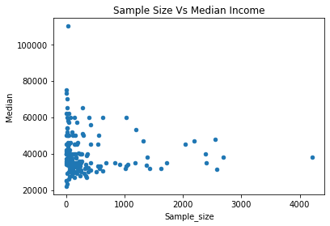

```python
recent_grads.plot(x='Sample_size', y='Median', kind='scatter', title='Sample Size Vs Median Income')
```

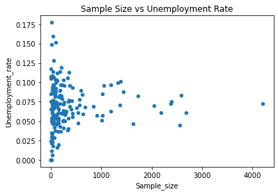

```python
recent_grads.plot(x='Sample_size', y='Unemployment_rate', kind='scatter', title ='Sample Size vs Unemployment Rate')
```

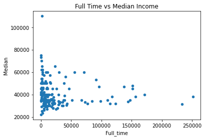

```python
recent_grads.plot(x='Full_time', y='Median', kind='scatter', title='Full Time vs Median Income')
```

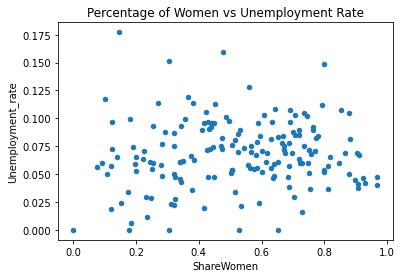

```python
recent_grads.plot(x='ShareWomen', y='Unemployment_rate', kind='scatter', title='Percentage of Women vs Unemployment Rate')
```

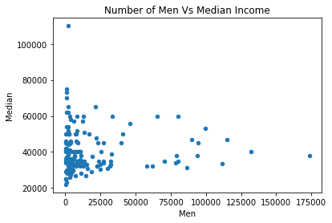

```python
recent_grads.plot(x='Men', y='Median', kind='scatter', title='Number of Men Vs Median Income')
```

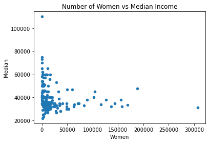

```python
recent_grads.plot(x='Women', y='Median', kind='scatter', title='Number of Women vs Median Income')
```

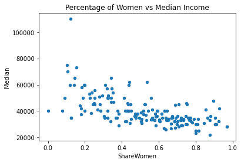

```python
#one extra plot to explore a relationship between the share of women and median income:
recent_grads.plot(x='ShareWomen', y='Median', kind='scatter', title='Percentage of Women vs Median Income')
```

- We can see that the higher the sample size, the lower the median salary in genera. With the majority of high income earners being in majors with the smallest sample sizes.
- Students in majors with majority female employees seem to make less than students in majors with majority male employees.
- There seems to be a slight negative relationship between the number of full time employees in a certain field and the median salary.

# 3 Examining the distribution of values in the dataset columns:

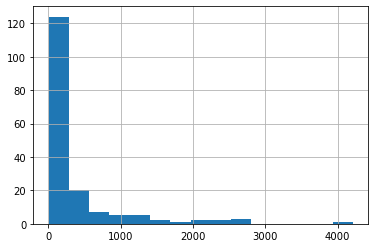

```python
#recent_grads['Sample_size'].plot(kind='hist'))
recent_grads['Sample_size'].hist(bins=15)
```

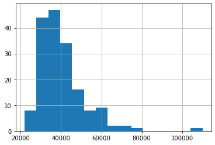

```python
recent_grads['Median'].hist(bins=15)
```

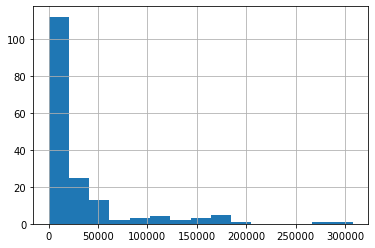

```python
recent_grads['Employed'].hist(bins=15)
```

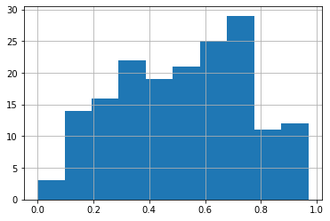

```python
recent_grads['ShareWomen'].hist(bins=10)
```

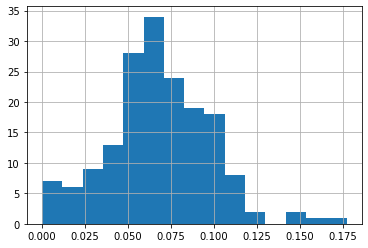

```python
recent_grads['Unemployment_rate'].hist(bins=15)
```

# 4 Using Scattered Matrix Plots to examine our data:

```
array([[<AxesSubplot:xlabel='Sample_size', ylabel='Sample_size'>,
        <AxesSubplot:xlabel='Median', ylabel='Sample_size'>],
       [<AxesSubplot:xlabel='Sample_size', ylabel='Median'>,
        <AxesSubplot:xlabel='Median', ylabel='Median'>]], dtype=object)
```

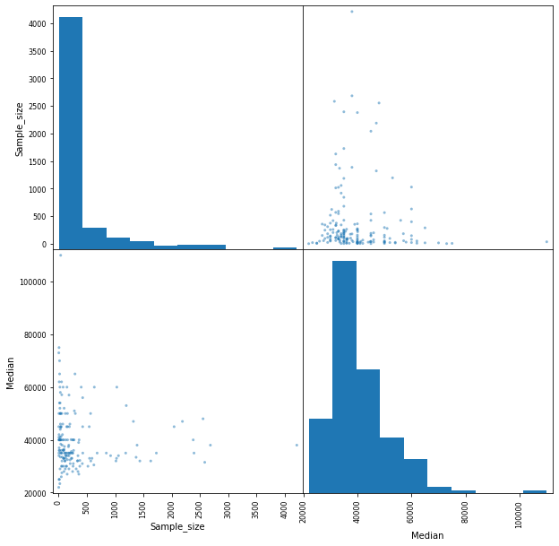

```python
from pandas.plotting import scatter_matrix

# Creating a scatter matrix of the sample size vs median salary
scatter_matrix(recent_grads[['Sample_size', 'Median']], figsize=(10,10))
```

```
array([[<AxesSubplot:xlabel='Sample_size', ylabel='Sample_size'>,
        <AxesSubplot:xlabel='Median', ylabel='Sample_size'>,
        <AxesSubplot:xlabel='Unemployment_rate', ylabel='Sample_size'>],
       [<AxesSubplot:xlabel='Sample_size', ylabel='Median'>,
        <AxesSubplot:xlabel='Median', ylabel='Median'>,
        <AxesSubplot:xlabel='Unemployment_rate', ylabel='Median'>],
       [<AxesSubplot:xlabel='Sample_size', ylabel='Unemployment_rate'>,
        <AxesSubplot:xlabel='Median', ylabel='Unemployment_rate'>,
        <AxesSubplot:xlabel='Unemployment_rate', ylabel='Unemployment_rate'>]],
      dtype=object)
```

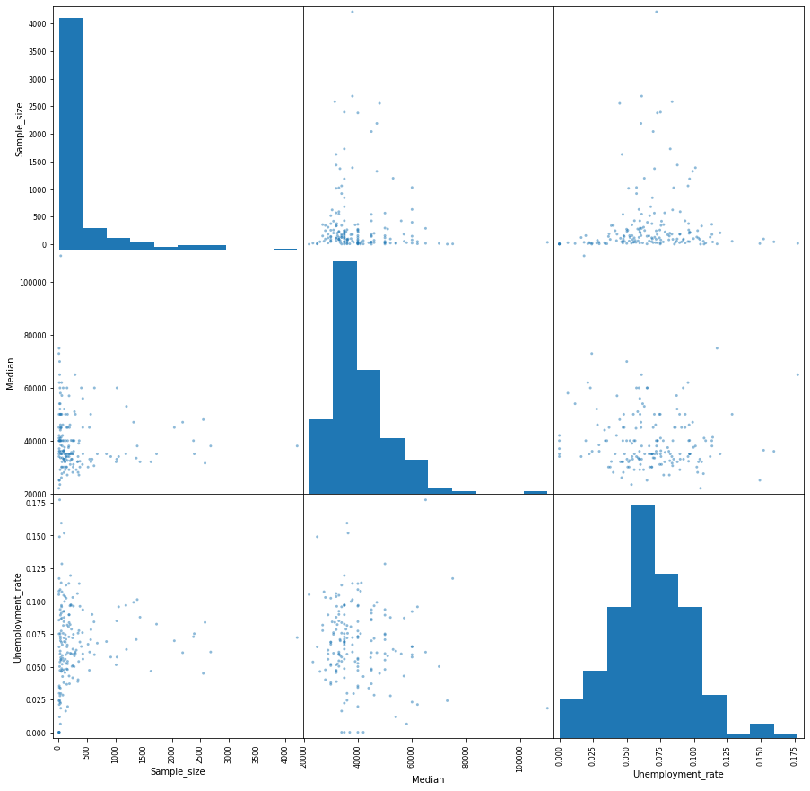

```python
# creating a scatter matrix of the sample size vs median salary vs unemployment rate
scatter_matrix(recent_grads[['Sample_size', 'Median', 'Unemployment_rate']], figsize=(15,15))
```

# 5 Exploring our data set with bar plots:

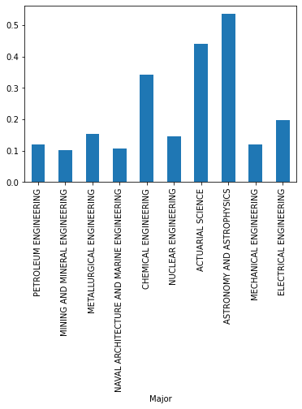

```python
# Displaying bar plots of the share of women in each major for the first 10 rows of our dataset
recent_grads[:10].plot.bar(x='Major', y='ShareWomen', legend=False)
```

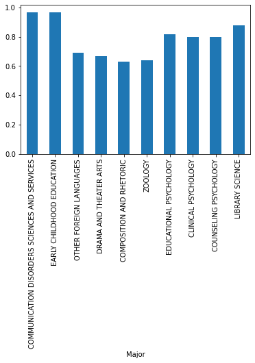

```python
# Displaying bar plots of the share of women in each major for the last 10 rows of our dataset
recent_grads[-10:].plot.bar(x='Major', y='ShareWomen', legend=False)
```

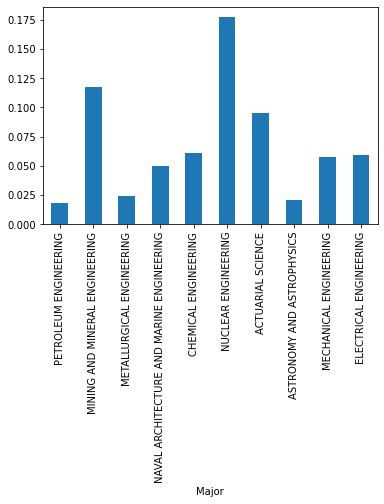

```python
# Comparing the unemployment rate for each major in the first 10 rows of our data set
recent_grads[:10].plot.bar(x='Major', y='Unemployment_rate', legend=False)
```

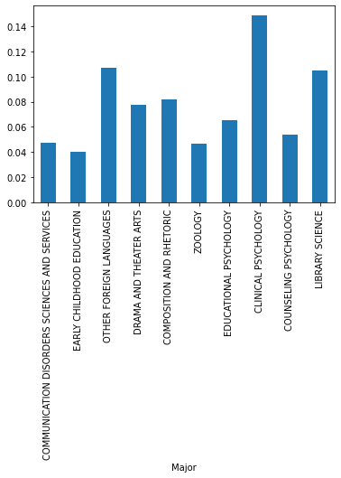

```python
# Comparing the unemployment rate for each major in the last 10 rows of our data set
recent_grads[-10:].plot.bar(x='Major', y='Unemployment_rate', legend=False)
```